# Week 6 Code walkthrough

# **************************************

# PART FOUR: CLASS EXERCISES *

# **************************************

# 1. Use the ozone.data.csv datafile:

# (a) use the datafile called ozone.data.csv;

# (b) explore the data to look at its structure, normality, linearity, heterogeneity;

# (c) create coplots to look for interactions between the variables;

# (d) create a multiplicative linear model to illustrate the what factors influences ozone levels in the city;

# (e) Use model averaging to select the most parsimonious model;

# (f) validate the ‘best’ model;

# (g) create the predictive model and generate the regression equation.

#ozone.data.csv DATAFILE CONTENTS: # Based on Daily readings of the following air quality values for May 1, 1973 (a Tuesday) # to September 30, 1973 in New York. # # Response - ozone: Mean ozone in parts per billion from 1300 to 1500 hours at Roosevelt Island # Explanatory - rad: Solar radiation in Langleys in the frequency band 4000–7700 Angstroms from 0800-1200 hours at Central Park # Explanatory - wind: Average wind speed in miles per hour at 0700 and 1000 hours at LaGuardia Airport # Explanatory - temp: Maximum daily temperature in degrees Fahrenheit at La Guardia Airport

Load libraries [check what needs installing]

```r
library(MuMIn)
library(tidyverse)
library(ggfortify)
library(car)
```

# Load file (file is in Dropbox; Teaching material; Courses…)

```r
setwd("~/Dropbox/Teaching-materials/COURSES/4TH_YR/Environmental Analysis & Modelling/GGM506 Data")
Ozone <- read.csv("ozone.data.csv", header = TRUE)
```

# look at data structure

```r
str(Ozone)
```

```
'data.frame':   111 obs. of  4 variables:
 $ rad  : int  190 118 149 313 299 99 19 256 290 274 ...
 $ temp : int  67 72 74 62 65 59 61 69 66 68 ...
 $ wind : num  7.4 8 12.6 11.5 8.6 13.8 20.1 9.7 9.2 10.9 ...
 $ ozone: int  41 36 12 18 23 19 8 16 11 14 ...
```

```r
head(Ozone)
```

|  | rad | temp | wind | ozone |
| --- | --- | --- | --- | --- |
| 1 | 190 | 67 | 7.4 | 41 |
| 2 | 118 | 72 | 8.0 | 36 |
| 3 | 149 | 74 | 12.6 | 12 |
| 4 | 313 | 62 | 11.5 | 18 |
| 5 | 299 | 65 | 8.6 | 23 |
| 6 | 99 | 59 | 13.8 | 19 |

# Draw pictures to explore it….

# Boxplots - normality

```r
op <- par(mfrow = c(2,2))
boxplot(Ozone$ozone, ylab="Ozone")
boxplot(Ozone$rad, ylab = "Solar Radiation")
```

```r
boxplot(Ozone$wind, ylab = "Wind")
boxplot(Ozone$temp, ylab = "Temperature")
```

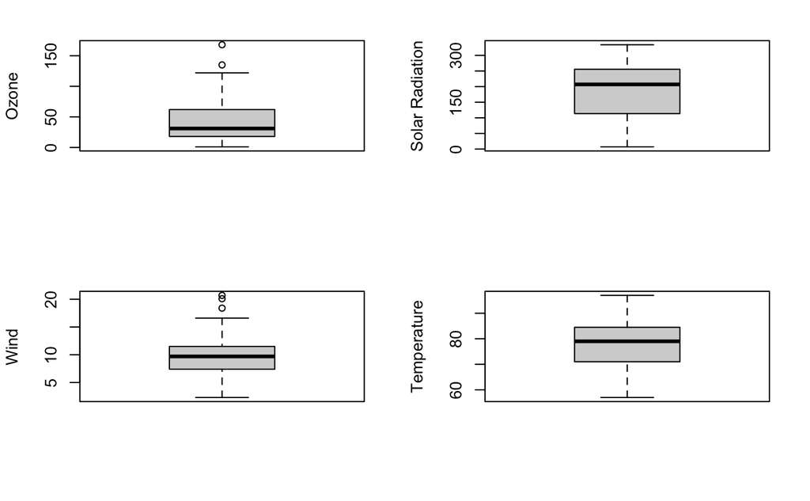

```r
par(op)
```

# Generally okay; wind and ozone have a few extreme values but it should be fine

# relationships between response and explanatories

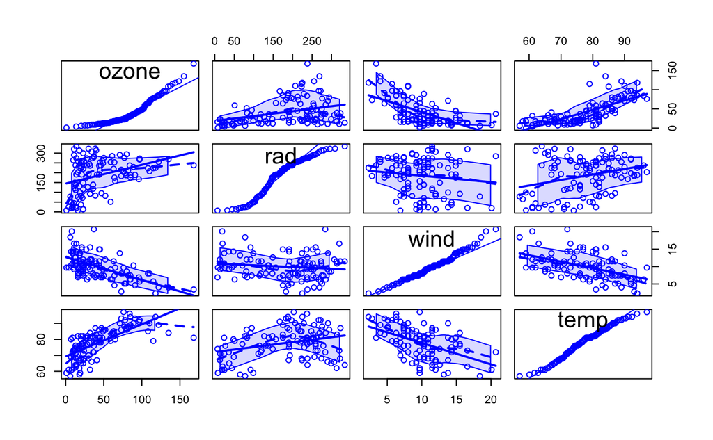

```r
scatterplotMatrix(~ozone + rad + wind + temp, data = Ozone, diagonal = list(method = "qqplot")) # use qqplot not boxplot
```

# Mixture of humped and linear X/Y relationships.

# Ozone ~ rad looks quadratic….ozone and rad slightly off normal.

# Might consider log10 transform if models are a mess.

# QQplots indicate that O2 and rad are a problem

# generate first full model using linear function. The full model uses all the interactions.

```r
M1 <- lm(ozone ~ rad * wind * temp, data = Ozone)
```

# look at summary

```r
summary(M1)
```

```
Call:
lm(formula = ozone ~ rad * wind * temp, data = Ozone)

Residuals:
    Min      1Q  Median      3Q     Max
-38.074 -11.194  -1.657   6.617  91.351

Coefficients:
                Estimate Std. Error t value Pr(>|t|)
(Intercept)   -7.131e+01  1.079e+02  -0.661    0.510
rad           -6.657e-01  5.871e-01  -1.134    0.260
wind           4.318e+00  8.881e+00   0.486    0.628
temp           1.347e+00  1.475e+00   0.913    0.363
rad:wind       3.403e-02  5.179e-02   0.657    0.513
rad:temp       1.099e-02  7.783e-03   1.412    0.161
wind:temp     -7.245e-02  1.254e-01  -0.578    0.565
rad:wind:temp -5.624e-04  6.999e-04  -0.804    0.423

Residual standard error: 19.19 on 103 degrees of freedom
Multiple R-squared:  0.6887,    Adjusted R-squared:  0.6675
F-statistic: 32.55 on 7 and 103 DF,  p-value: < 2.2e-16
```

# Nothing appears to be significant.

# need to simplify this a little….but first we need to check for inflationary values

# Note that any exponent will lead to inflation….

```r
vif(lm(ozone ~ rad * wind * temp, data = Ozone))
```

```
          rad          wind          temp      rad:wind      rad:temp     wind:temp
    855.78646     298.52903      59.00957    1112.86766     994.77835     285.41931
rad:wind:temp
   1159.32469
```

# but interaction terms are huge so remove the 3-way and largest 2-ways ones.

```r
vif(lm(ozone ~ rad + wind + temp+ wind:temp, data = Ozone))
```

```
      rad      wind      temp wind:temp
 1.100040 61.856957  8.501469 48.005255
```

# Chuck out wind as it is huge leaving the interaction with wind and temp.

# Our understanding how wind impacts temperature and ozone production suggests this is sensible.

```r
vif(lm(ozone ~ rad + temp + wind:temp, data = Ozone))
```

```
      rad      temp temp:wind
 1.095810  1.128567  1.031379
```